# Evaluating Fisheries Data Quality for Inseason Management

2022-12-30

# Introduction

One of the purposes for which fishery-dependent data are used is inseason management, broadly defined as the opening and closing of fisheries throughout the year based on the proportion of total allowable catch (TAC) that has been harvested or the proportion of prohibited species catch (PSC) that has been caught, relative to PSC limits. Catch that accrues toward TAC or PSC limits is assigned by the Catch Accounting System (CAS) to different accounts. These accounts are the units within which catch is tracked by inseason management, and so they will form the basis of this analysis. This is a table of all the accounts used in 2021 for catch contained within the Valhalla data set:

| AI Greenland Turbot | BSAI Herring - Turbot/Arrowtooth/Kamchatka/Sablefish TRW | CGOA (620 Chirikof) Pollock | GOA PWS Arrowtooth Flounder | GOA SE Outside POP |
| --- | --- | --- | --- | --- |
| AI Other Rockfish | BSAI Herring - Yellowfin Sole TRW | CGOA (630 Kodiak) Pollock | GOA PWS Big Skate | GOA SE Outside Rex Sole |
| AI Pcod CDQ | BSAI Kamchatka Flounder | CGOA Arrowtooth Flounder | GOA PWS Deep Water Flatfish | GOA SE Outside Sablefish HAL |
| AI Pollock ICA | BSAI Non Chinook Salmon Non TRW | CGOA Big Skate | GOA PWS Dusky Rockfish | GOA SE Outside Shallow Water Flatfish |
| AI Sablefish HAL/Pot | BSAI Non Chinook Salmon PSQ | CGOA Deep Water Flatfish | GOA PWS Flathead Sole | GOA Shark |
| AI Sablefish HAL/Pot CDQ | BSAI Non Chinook Salmon TRW | CGOA Dusky Rockfish | GOA PWS Longnose Skate | GOA Shark PWS |
| AI Sablefish TRW | BSAI Northern Rockfish | CGOA Flathead Sole | GOA PWS Other Rockfish | GOA Shark SE Inside |
| AI Sablefish TRW CDQ | BSAI Octopus | CGOA Longnose Skate | GOA PWS Pcod HAL State Fishery | GOA West Yakutat Arrowtooth Flounder |
| Bogoslof Pollock ICA | BSAI Other Flatfish | CGOA Northern Rockfish | GOA PWS Pollock | GOA West Yakutat Deep Water Flatfish |
| BS Chinook Salmon - Pollock PTR | BSAI Pcod HAL CP | CGOA Pcod | GOA PWS POP | GOA West Yakutat Dusky Rockfish |
| BS Chinook Salmon PSQ | BSAI Pcod HAL/Pot CV < 60 ft | CGOA POP | GOA PWS Rex Sole | GOA West Yakutat Flathead Sole |
| BS Greenland Turbot | BSAI Pcod ICA HAL/Pot | CGOA Rex Sole | GOA PWS Rougheye Rockfish | GOA West Yakutat Other Rockfish (slope rockfish) |
| BS Greenland Turbot CDQ | BSAI Pcod Pot CP | CGOA Rougheye Rockfish | GOA PWS Sablefish HAL | GOA West Yakutat Pollock |
| BS Other Rockfish | BSAI Pcod Pot CV >=60 | CGOA Sablefish HAL | GOA PWS Shallow Water Flatfish | GOA West Yakutat POP |
| BS Pcod CDQ | BSAI Pcod TRW CP Coop AFA | CGOA Sablefish TRW | GOA PWS Shortraker Rockfish | GOA West Yakutat Rex Sole |
| BS Pollock CDQ | BSAI Pcod TRW CP Non-AFA | CGOA Shallow Water Flatfish | GOA PWS Thornyhead Rockfish | GOA West Yakutat Sablefish HAL |
| BS Pollock CP | BSAI Pcod TRW CV | CGOA Shortraker Rockfish | GOA Retained Halibut | GOA West Yakutat Sablefish TRW |
| BS Pollock ICA | BSAI Retained Halibut | CGOA Thornyhead Rockfish | GOA SE Inside Arrowtooth Flounder | GOA West Yakutat Shallow Water Flatfish |
| BS Pollock Inshore | BSAI Rock Sole | Cook Inlet and North Gulf Sablefish State Fishery | GOA SE Inside Big Skate | WAI Atka Mackerel CDQ |
| BS Pollock Mothership | BSAI Rock Sole CDQ | EAI POP | GOA SE Inside Deep Water Flatfish | WAI Atka Mackerel ICA |
| BS POP | BSAI Shark | EAI POP CDQ | GOA SE Inside Demersal Shelf Rockfish | WAI Atka Mackerel TRW |
| BS Sablefish HAL/Pot | BSAI Shortraker Rockfish | EGOA Big Skate | GOA SE Inside Dusky Rockfish | WAI POP |
| BS Sablefish HAL/Pot CDQ | BSAI Skate | EGOA Longnose Skate | GOA SE Inside Flathead Sole | WAI POP CDQ |
| BS Sablefish TRW | BSAI Yellowfin Sole | EGOA Pcod | GOA SE Inside Longnose Skate | Western/Central GOA Other Rockfish |
| BS Sablefish TRW CDQ | BSAI Yellowfin Sole CDQ | EGOA Rougheye Rockfish | GOA SE Inside Other Rockfish | WGOA (610 Shumagin) Pollock |
| BSAI Alaska Plaice | BSAI Zone 1 Bairdi Crab | EGOA Shortraker Rockfish | GOA SE Inside Pcod | WGOA Arrowtooth Flounder |
| BSAI Arrowtooth Flounder | BSAI Zone 1 Bairdi Crab PSQ | EGOA Thornyhead Rockfish | GOA SE Inside Pollock | WGOA Big Skate |
| BSAI Arrowtooth Flounder CDQ | BSAI Zone 1 Red King Crab | GOA Atka Mackerel | GOA SE Inside POP | WGOA Deep Water Flatfish |
| BSAI Chinook PSC NON-PTR | BSAI Zone 1 Red King Crab PSQ | GOA Chinook Salmon TRW | GOA SE Inside Rex Sole | WGOA Dusky Rockfish |
| BSAI COBLZ Opilio Crab | BSAI Zone 2 Bairdi Crab | GOA Cook Inlet Pcod Jig State Fishery | GOA SE Inside Rougheye Rockfish | WGOA Flathead Sole |
| BSAI COBLZ Opilio Crab PSQ | BSAI Zone 2 Bairdi Crab PSQ | GOA Cook Inlet Pcod Pot State Fishery | GOA SE Inside Sablefish HAL | WGOA Longnose Skate |
| BSAI Flathead Sole | BSEAI Atka Mackerel CDQ | GOA Halibut - Species other than Demersal Shelf Rockfish HAL | GOA SE Inside Shallow Water Flatfish | WGOA Northern Rockfish |
| BSAI Flathead Sole CDQ | BSEAI Atka Mackerel ICA | GOA Halibut TRW | GOA SE Inside Shortraker Rockfish | WGOA Pcod |
| BSAI Halibut Non-TRW | BSEAI Atka Mackerel TRW | GOA Kodiak Pcod Jig State Fishery | GOA SE Inside Thornyhead Rockfish | WGOA POP |
| BSAI Halibut PSQ | BSEAI Rougheye Rockfish | GOA Non Chinook Salmon TRW | GOA SE Outside Arrowtooth Flounder | WGOA Rex Sole |
| BSAI Halibut TRW | CAI-WAI Rougheye Rockfish | GOA Octopus | GOA SE Outside Deep Water Flatfish | WGOA Rougheye Rockfish |
| BSAI Herring - Pcod TRW | CAI Atka Mackerel CDQ | GOA Octopus PWS | GOA SE Outside Demersal Shelf Rockfish | WGOA Sablefish HAL |
| BSAI Herring - Pollock PTR | CAI Atka Mackerel ICA | GOA Octopus SE Inside | GOA SE Outside Dusky Rockfish | WGOA Sablefish TRW |
| BSAI Herring - Pollock/Atka Mackerel /Other TRW | CAI Atka Mackerel TRW | GOA Other Skates | GOA SE Outside Flathead Sole | WGOA Shallow Water Flatfish |
| BSAI Herring - Rockfish TRW | CAI POP | GOA Other Skates PWS | GOA SE Outside Other Rockfish (slope rockfish) | WGOA Shortraker Rockfish |
| BSAI Herring - Rsole/ Fsole/ Oflat TRW | CAI POP CDQ | GOA Other Skates SE Inside | GOA SE Outside Pollock | WGOA Thornyhead Rockfish |

# The Goal of This Analysis

The goal of this analysis is to identify a metric that can be used to differentiate the performance of different sampling designs with regards to how well they provide data for inseason management. It’s important to note that the goal is *not* to identify the absolute best metric for measuring design performance for inseason management; the metric only needs to be accurate enough to differentiate between the performance of different sampling designs. The goal is also *not* to quantify how much data is needed for inseason management.

# What’s a Good Sampling Design for Inseason Mangement?

Catch is either retained or discarded. Retained catch is known, whereas discarded catch is estimated. With more precise estimates, an inseason manager is able to close a fishery closer to its TAC or PSC limit. Discard estimates are made using data from fisheries observers or electronic monitoring (EM). More monitoring data (from observers or EM) won’t benefit inseason management if it’s directed toward a fishery that retains all catch. Therefore, a sampling design that dedicates more sampling toward fisheries with a lot of highly variable discards will outperform a design that puts more sampling toward fisheries with small amounts of discards with little variance.

It’s therefore helpful to visualize how much of the catch in each account is made up of discards:

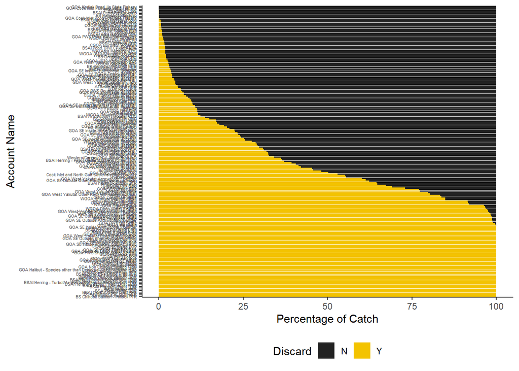

It’s also helpful to visualize how much catch occurs in partial coverage within each account:

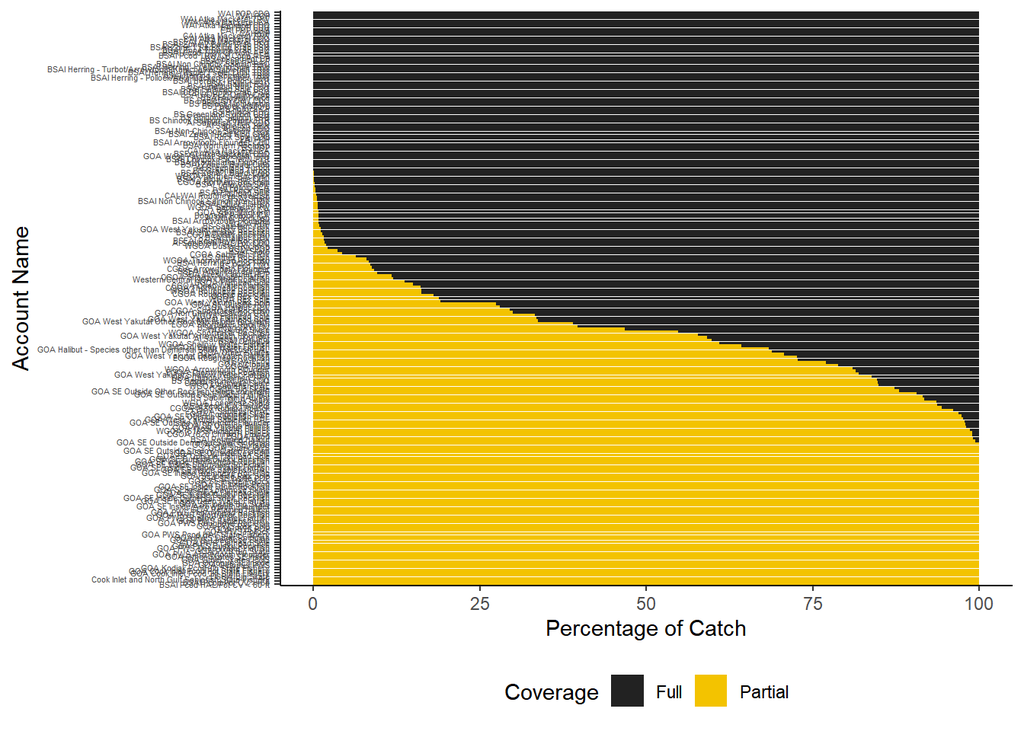

Although the patterns in these plots are very similar, the account names on the y-axes are not in the same order. Let’s look at the graphs side by side with the same account order:

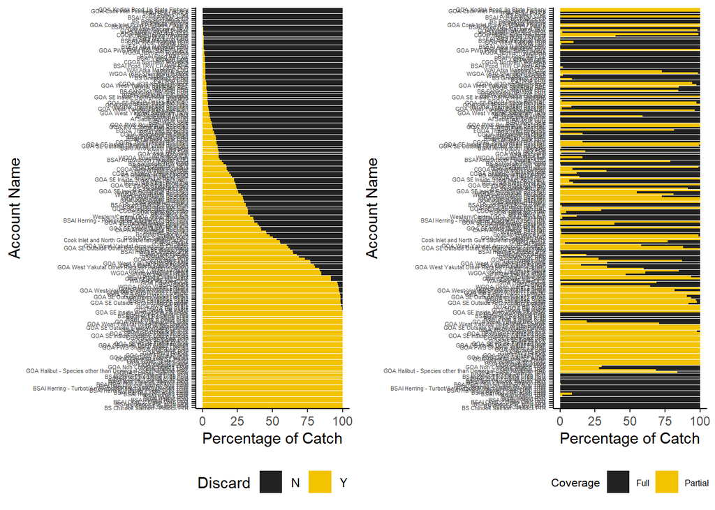

This shows that accounts with a high proportion of discards aren’t necessarily in full coverage. There are several accounts in which all catch was discarded and fell within partial coverage. But we aren’t interested in discard *amount*, we are interested in discard *variability*, so let’s look at the variability of discards that occurred on observed trips relative to realized coverage rates within each account:

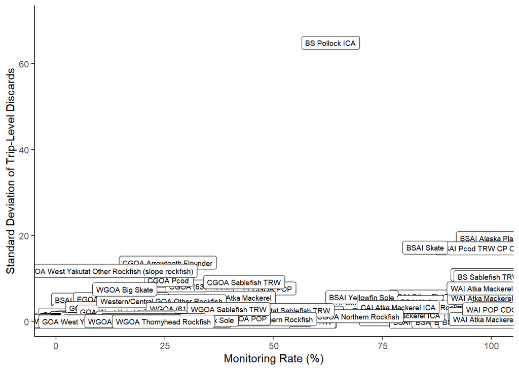

There’s clearly an outlier in BS Pollock Incidental Catch Allowance (ICA), but standard deviation isn’t quite what we’re after anyway, because highly variable discards at the trip level would still be precisely estimated if monitoring rates are high. We’re interested in the standard deviation of the *estimate*. In this case, the estimate of the amount of discards that occurred within the account. The standard deviation of an estimate is called standard error, and we can begin by first calculating the standard error of the mean amount of discards that occurred on each trip within an account by using the following equation:

$SE_{t} = \sqrt{\frac{N - n}{N} \frac{1}{n} \frac{\sum_{i=1}^{n} (d_{i}-\bar{d})^2}{n-1}}$

Where $N$ is the total number of trips that occurred within an account, $n$ is the total number of monitored trips that occurred within an account, each $d_{i}$ is the amount of discards that occurred on a monitored trip, and $\bar{d}$ is the mean amount of discards that occurred on monitored trips within that account. We use the finite population correction factor ($\frac{N - n}{N}$) to account for the proportion of the population being sampled. The standard error of the estimate of the total amount of catch that occurred with in an account is this trip-level standard error multiplied by the total number of trips in that account:

$SE_{a} = SE_{t}N$

This plot shows the account-level standard error against monitoring rate for each account:

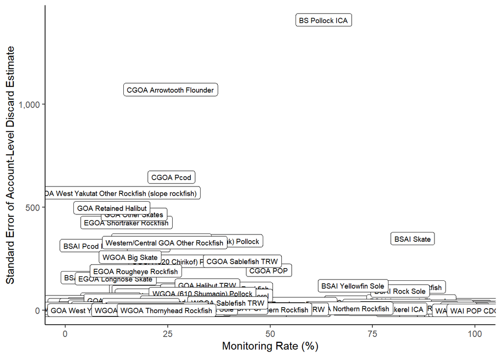

It might be more useful to look at the distribution of standard errors:

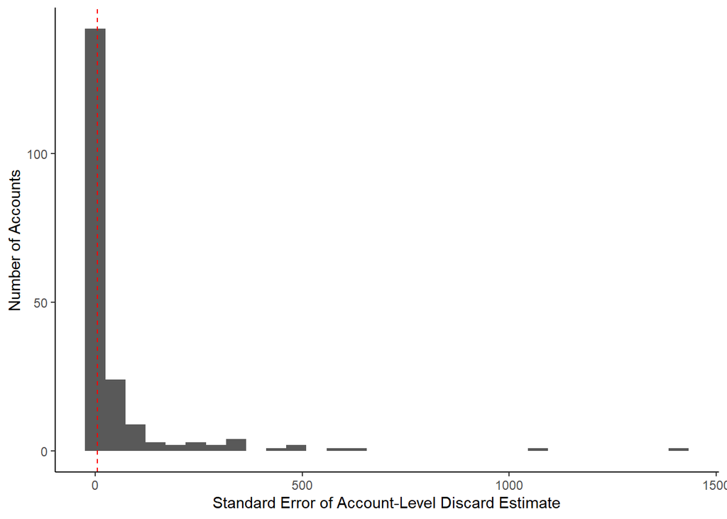

The dashed red line represents the median standard error across accounts. A sampling design with a lower median standard error would be better for inseason management since it would mean that on average, the amount of discards that occurred within any given account were estimated with more precision. So far this analysis has been using 2021 data and the actual sampling that occurred in that year. All monitored trips were counted, regardless of whether they were monitored by an observer or EM. However, when the 2024 analytic team met with inseason managers, a consistent message from them was that fixed-gear EM isn’t currently very useful for inseason management, since data often come in weeks or months after the trip occurred. As a test of median standard error as a metric for differentiating between sample design performance for inseason management, we could compare what actually occurred in 2021 with a mock data set that only counts 25% of fixed-gear trips monitored with EM as having been monitored. This number was chosen based on inseason manager’s assessment that 1 week is about the maximum turnaround time EM data could have to still be useful for inseason management and the fact that the 2020 Annual Report (AFSC and AKRO 2021) showed that even the 25th percentile of review times (from hard drive received to data exported) was 9 days and 16 days for hook-and-line and pot gear, respectively. Comparing the mock design that only counts 25% of the monitored fixed-gear EM trips against what actually occurred in 2021, we get this:

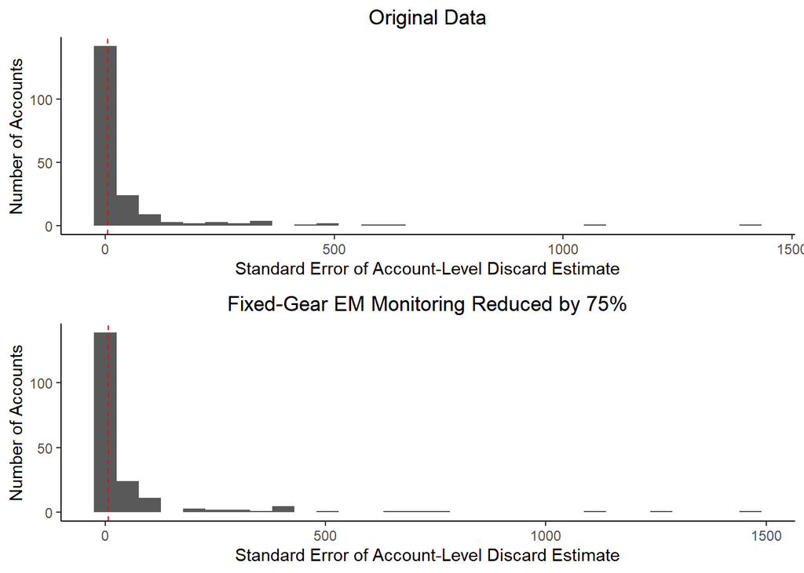

It’s hard to see a difference in medians from the graph, so here they are in table form:

| Design | Median Standard Error |
| --- | --- |
| Original | 5.58 |
| Reduced EM | 6.68 |

The mock design used a random draw of monitored fixed-gear EM trips, and we can see that repeating that process consistently results in median standard errors that are higher than what actually occurred in 2021:

| Design | Median Standard Error |
| --- | --- |
| Original | 5.58 |
| Reduced EM 1 | 6.68 |
| Reduced EM 2 | 6.98 |
| Reduced EM 3 | 7.23 |
| Reduced EM 4 | 6.92 |
| Reduced EM 5 | 6.67 |

This tells us that if all fixed-gear EM data were usable for inseason management, that design would perform better than one in which only 25% of fixed-gear EM data are usable for inseason management. Median standard error is the metric being proposed for differentiating the performance of different sampling designs with regards to providing data for inseason management.

# Potential Criticisms of This Approach

1. The standard error estimates are wrong because they assume that catch is known with perfect accuracy at the trip-level.
2. Trip counts are wrong because estimates were included when counting the number of trips that contributed catch to an account, and those estimates were made based on current CAS post-stratification rules.

# Responses to Potential Criticisms

1. Assuming catch is known at the trip-level is an intentional simplification. That simplification prevents the standard error estimates from being published as accurate, but it does not prevent this approach from being used to differentiate between the performance of designs.
2. Total catch estimates are our best approximation of what catch occurred on each trip. If post-stratification methods provide more precise total catch estimates in the future, it will only benefit the approach used here.

# Open Questions

1. Should accounts with PSC limits be treated differently than accounts without PSC limits?

# References

AFSC (Alaska Fisheries Science Center) and AKRO (Alaska Regional Office). 2021. North Pacific Observer Program 2020 Annual Report. AFSC Processed Rep. 2021-03, 143 p. Alaska Fish. Sci. Cent., NOAA, Natl. Mar. Fish. Serv., 7600 Sand Point Way NE, Seattle WA 98115.Available at https://repository.library.noaa.gov/view/noaa/30732.